# Test 2, STAT 245 for bs47

Author

STAT 245 Fall 2024

## Response variable

Fit a regression model using as your response variable: whether female flies successfully produced offspring (“pupae”).

## Data Access

You can find your data at: https://sldr.netlify.app/data/hot-flies.csv

## Context

This dataset was recently analyzed by Hester Weaving and colleagues in the paper [*Heatwaves are detrimental to fertility in the viviparous tsetse fly*](https://royalsocietypublishing.org/doi/10.1098/rspb.2023.2710#d1e528).

Tsetse flies are African insects that can carry sleeping sickness and other diseases.

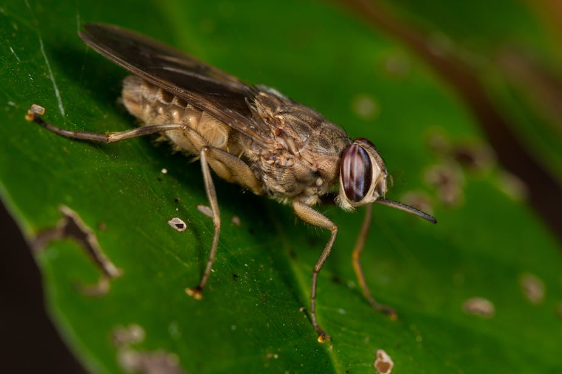

Image from theconversation.com

The researchers state,

> > Heatwaves are increasing in frequency and intensity due to climate change, pushing animals beyond physiological limits. While most studies focus on survival limits, sublethal effects on fertility tend to occur below lethal thresholds, and consequently can be as important for population viability. … Here, we measured the effect of experimental heatwaves on tsetse flies, *Glossina pallidipes*, disease vectors and unusual live-bearing insects of sub-Saharan Africa. We exposed males or females to a 3-day heatwave peaking at 36, 38 or 40 degrees Celsius for 2 h, and a 25 degrees C control, monitoring mortality and reproduction over six weeks. For a heatwave peaking at 40 degrees C, mortality was 100%, while a 38 degree C peak resulted in only 8% acute mortality. Females exposed to the 38 degree C heatwave experienced a one-week delay in producing offspring, whereas no such delay occurred in males. Over six weeks, heatwaves resulted in equivalent fertility loss in both sexes. Combined with mortality, this lead to a 10% population decline over six weeks compared to the control. Furthermore, parental heatwave exposure gave rise to a female-biased offspring sex ratio. Ultimately, thermal limits of both survival and fertility should be considered when assessing climate change vulnerability.

Can you replicate some of the study’s findings with your analysis?

Variables in the dataset include:

- `cage_ID`: which cage the flies were housed in
- `temperature` at which the trials took place, in degrees Celsius
- `week_number` and `day_number`: time of observation. Each week of the study contains 7 days.
- `produced_pupae`: number of females that successfully produced pupae
- `no_pupae`: number of females that did not produce any pupae
- `n_females`: total number of females alive
- `prop_pupae` = `produced_pupae` / `n_females`